# Locker-Angelina-ADA-Homework-02

Angelina Locker

February 27, 2019

1. Every Saturday, at the same time, a primatologist goes and sits in the forest in the morning and listens for titi monkey calls, counting the number of calls they hear in a 2 hour window from 5am to 7am. Based on previous knowledge, she believes that the mean number calls she will hear in that time is 15. Let X represent the appropriate Poisson random variable of the number of calls heard in each monitoring session.

```r
x <- 0:30
```

1.a. What is the probability that she will hear more than 8 calls during any given session?

```r
x <- 0:30
l <- 15
a <- ppois(q = 8, lambda = 15)
eightplus <- 1-a
eightplus
```

```
## [1] 0.9625535
```

1.b. What is the probability that she will hear no calls in a session?

```r
x <- 0:30
l <- 15
b <- ppois(q = 0, lambda = 15)
zero <- 1-b
zero
```

```
## [1] 0.9999997
```

1.c. What is the probability that she will hear exactly 3 calls in a session?

```r
x <- 0:30
l <- 15
c <- dpois(x = 3, lambda = 15)
exactthree <- 1-c
exactthree
```

```
## [1] 0.9998279
```

1.d. Plot the relevant Poisson mass function over the values in range 0 ≤ x ≤ 30.

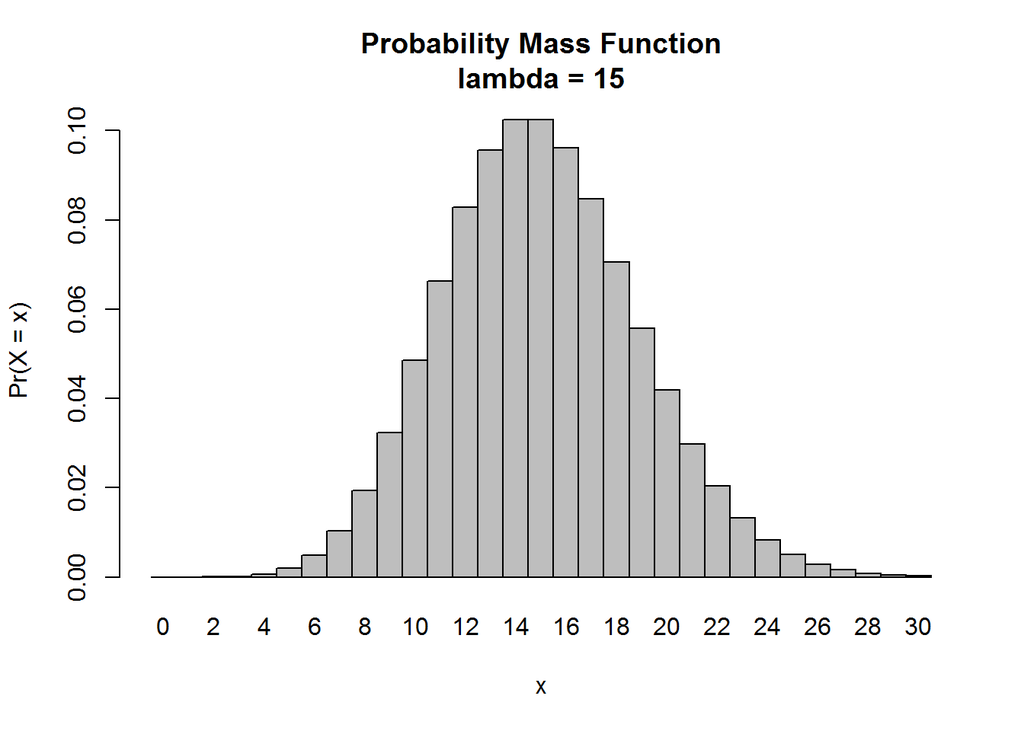

```r
x <- 0:30
l <- 15
probset <- dpois(x = x, lambda = l)
barplot(probset, names.arg = x, space = 0, xlab = "x", ylab = "Pr(X = x)", main = paste0("Probability Mass Function\nlambda = ", 15))
```

1.e. Simulate 104 results from this distribution (i.e., 2 years of Saturday monitoring sessions).

```r
x <- 0:30
l <- 15

two_year <- rpois(n = 104, lambda = 15)


two_year
```

```
##   [1] 16 21 14 22 11 13 15  7 14 10 15 12 21 15 16 24 16 15 20 12 15 13 21
##  [24] 11 15 15 22 22 19 15  8 15 14 19 17 23 12 17 23 15 11 11 15  8 12 17
##  [47] 16 13  9 13 18  8 16 17 15 20 20 12 11 18 12 13 26 15 19 17 20 20 12
##  [70] 20 12 18 10 17 20 22 19 15 14 10 14 20 18 18 10 19 11 14 20 12 12 21
##  [93] 18 11 10 13 13 19 21 13 12 20  9 26
```

1.f. Plot the simulated results using hist() and use xlim() to set the horizontal limits to be from 0 to 30. How does your histogram compare to the shape of the probability mass function you plotted above?

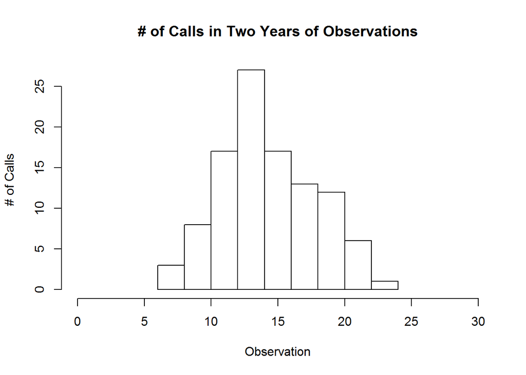

```r
two_year <- rpois(n = 104, lambda = 15)

hist(two_year, xlim=c(0,30), xlab = "Observation", ylab = "# of Calls", main = "# of Calls in Two Years of Observations")
```

2. Load in the dataset “zombies.csv” from my GitHub repository at https://github.com/difiore/ADA-2019. This data includes the first and last name and gender of the entire population of 1000 people who have survived the zombie apocalypse and are now ekeing out an existence somewhere on the East Coast, along with several other variables (height, weight, age, number of years of education, number of zombies they have killed, and college major see here for info on important post-zombie apocalypse majors

```r
d <- read.csv(file = "C:/Users/ajlocker/Desktop/Data Analysis/zombies.csv", sep = ",", header =  TRUE, stringsAsFactors = FALSE)
head(d)
```

```
##   id first_name last_name gender   height   weight zombies_killed
## 1  1      Sarah    Little Female 62.88951 132.0872              2
## 2  2       Mark    Duncan   Male 67.80277 146.3753              5
## 3  3    Brandon     Perez   Male 72.12908 152.9370              1
## 4  4      Roger   Coleman   Male 66.78484 129.7418              5
## 5  5      Tammy    Powell Female 64.71832 132.4265              4
## 6  6    Anthony     Green   Male 71.24326 152.5246              1
##   years_of_education                           major      age
## 1                  1                medicine/nursing 17.64275
## 2                  3 criminal justice administration 22.58951
## 3                  1                       education 21.91276
## 4                  6                  energy studies 18.19058
## 5                  3                       logistics 21.10399
## 6                  4                  energy studies 21.48355
```

2.a. Calculate the population mean and standard deviation for each quantitative random variable (height, weight, age, number of zombies killed, and years of education). NOTE: You will not want to use the built in var() and sd() commands as those are for samples.

```r
library(tidyverse)
library(psych)
sel_data <- select(d,height, age, weight, zombies_killed, years_of_education)

describe(sel_data)
```

```
##                    vars    n   mean    sd median trimmed   mad   min
## height                1 1000  67.63  4.31  67.50   67.58  4.23 54.15
## age                   2 1000  20.05  2.97  19.90   20.01  2.88 10.66
## weight                3 1000 143.91 18.40 142.89  143.71 18.08 90.29
## zombies_killed        4 1000   2.99  1.75   3.00    2.87  1.48  0.00
## years_of_education    5 1000   3.00  1.68   3.00    2.92  1.48  0.00
##                       max  range skew kurtosis   se
## height              80.53  26.38 0.08    -0.01 0.14
## age                 29.59  18.93 0.13     0.10 0.09
## weight             210.79 120.50 0.13    -0.01 0.58
## zombies_killed      11.00  11.00 0.67     0.54 0.06
## years_of_education   8.00   8.00 0.40    -0.21 0.05
```

```r
sd_height <- sqrt(sum((d$height-mean(d$height))^2)/length(d$height))

sd_weight <- sqrt(sum((d$weight-mean(d$weight))^2)/length(d$weight))

sd_age <- sqrt(sum((d$age-mean(d$age))^2)/length(d$age))

sd_kills <- sqrt(sum((d$zombies_killed-mean(d$zombies_killed))^2)/length(d$zombies_killed))

sd_edu <- sqrt(sum((d$years_of_education-mean(d$years_of_education))^2)/length(d$years_of_education))

mean_height <- mean(d$height)

mean_weight <- mean(d$weight)

mean_age <- mean(d$age)

mean_kills <- mean(d$zombies_killed)

mean_edu <- mean(d$years_of_education)


sd_height
```

```
## [1] 4.30797
```

```r
sd_age
```

```
## [1] 2.963583
```

```r
sd_weight
```

```
## [1] 18.39186
```

```r
sd_kills
```

```
## [1] 1.747551
```

```r
sd_edu
```

```
## [1] 1.675704
```

```r
mean_height
```

```
## [1] 67.6301
```

```r
mean_age
```

```
## [1] 20.04696
```

```r
mean_weight
```

```
## [1] 143.9075
```

```r
mean_kills
```

```
## [1] 2.992
```

```r
mean_edu
```

```
## [1] 2.996
```

2.b. Use {ggplot} and make boxplots of each of these variable by gender.

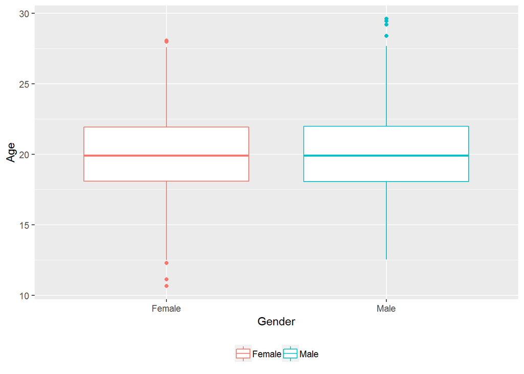

```r
library(tidyverse)
library(ggplot2)
abox <- ggplot(data = d, aes(x = gender, y = age, color = gender)) + xlab("Gender") + ylab("Age") + geom_boxplot(na.rm = TRUE) + theme(legend.position = "bottom", legend.title = element_blank())
abox
```

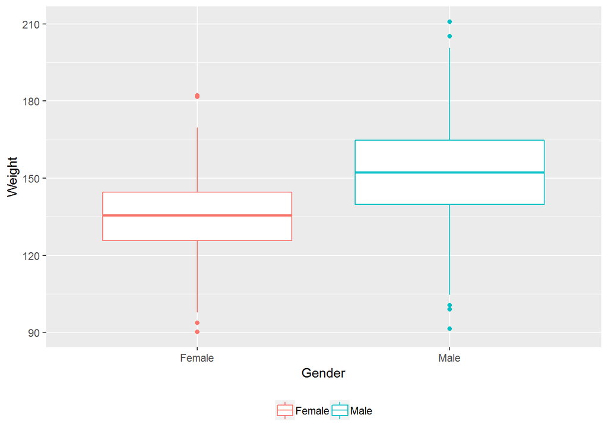

```r
wbox <- ggplot(data = d, aes(x = gender, y = weight, color = gender)) + xlab("Gender") + ylab("Weight") + geom_boxplot(na.rm = TRUE) + theme(legend.position = "bottom", legend.title = element_blank())
wbox
```

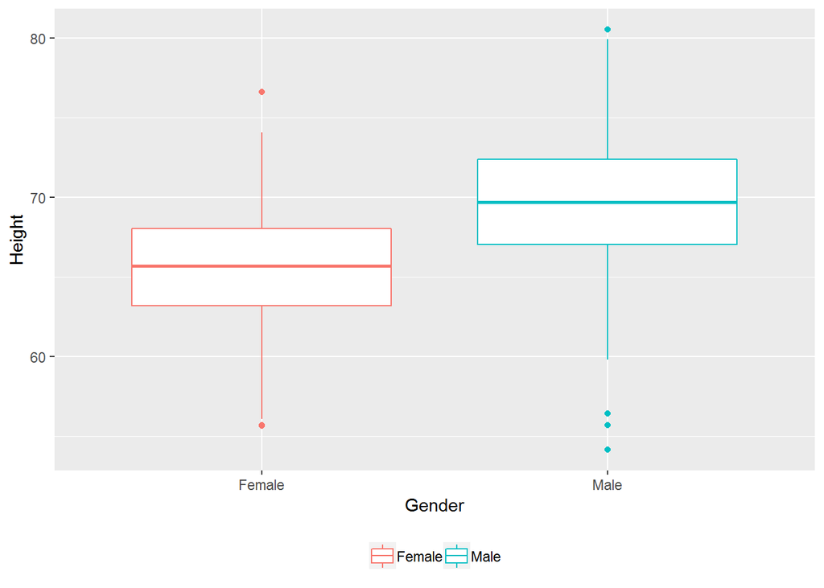

```r
hbox <- ggplot(data = d, aes(x = gender, y = height, color = gender)) + xlab("Gender") + ylab("Height") + geom_boxplot(na.rm = TRUE) + theme(legend.position = "bottom", legend.title = element_blank())
hbox
```

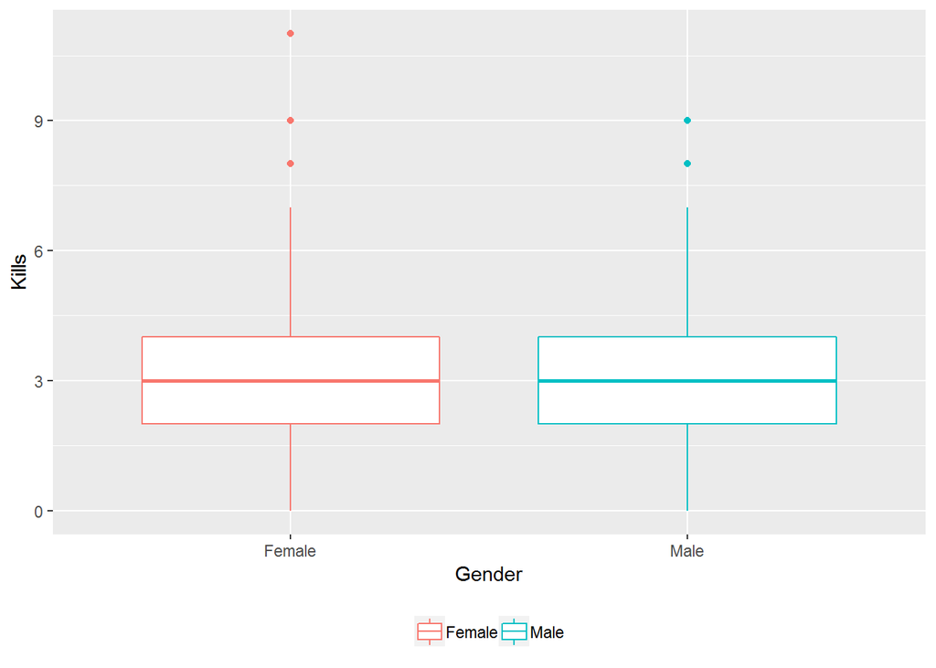

```r
zbox <- ggplot(data = d, aes(x = gender, y = zombies_killed, color = gender)) + xlab("Gender") + ylab("Kills") + geom_boxplot(na.rm = TRUE) + theme(legend.position = "bottom", legend.title = element_blank())
zbox
```

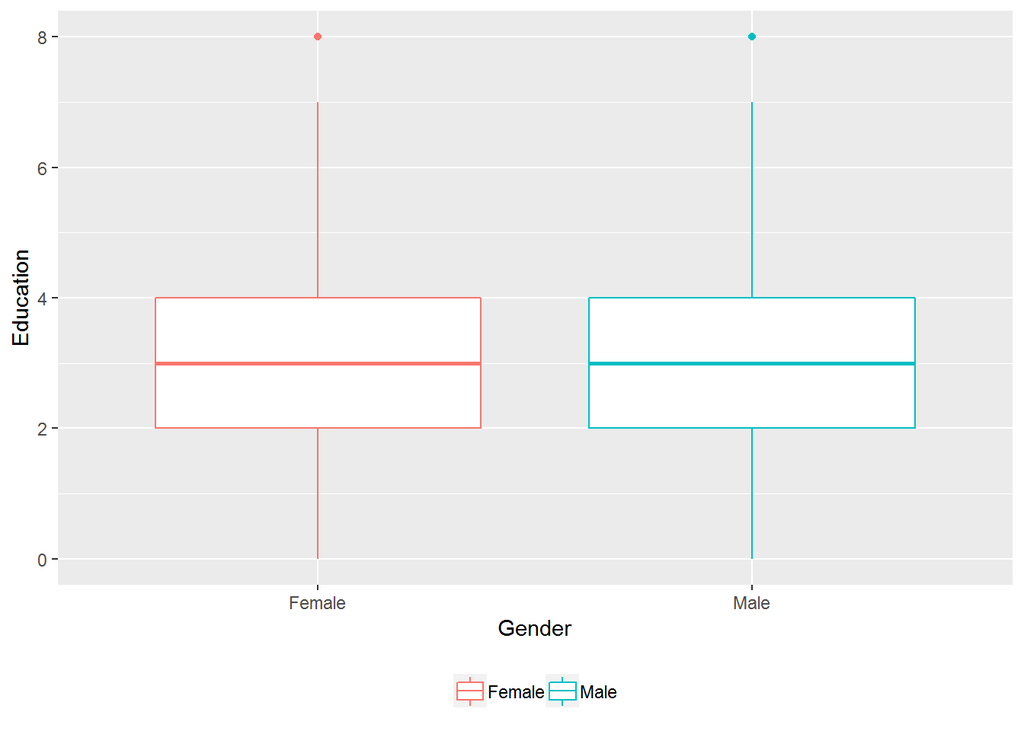

```r
ebox <- ggplot(data = d, aes(x = gender, y = years_of_education, color = gender)) + xlab("Gender") + ylab("Education") + geom_boxplot(na.rm = TRUE) + theme(legend.position = "bottom", legend.title = element_blank())
ebox
```

2.c. Use {ggplot} and make scatterplots of height and weight in relation to age. Do these variables seem to be related? In what way? *Both height and weight, in relation to age, have positive linear correlations. Height and age is a stong(ish) positive linear correlation; weight and age is a weak positive linear correlation*

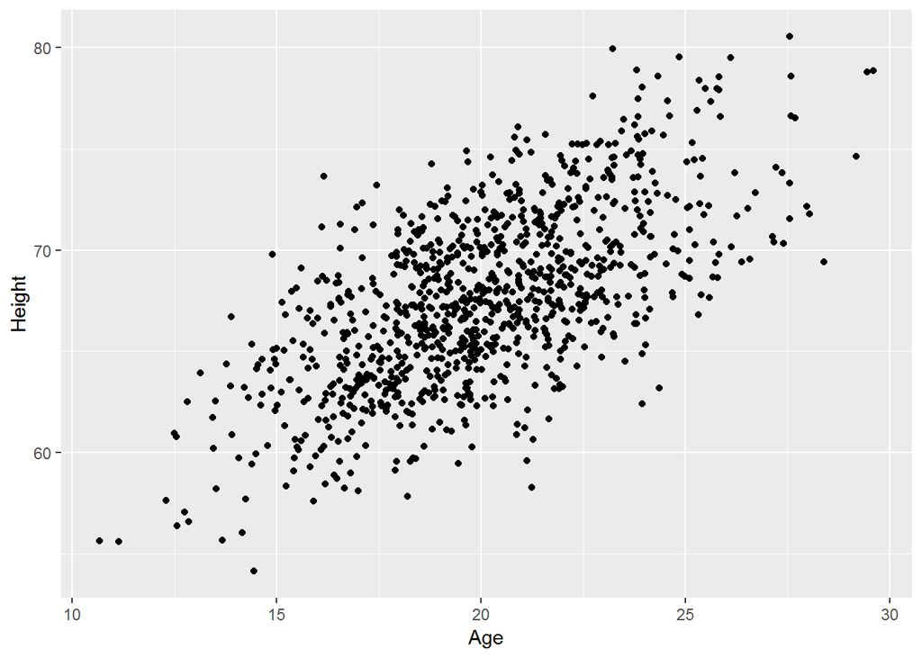

```r
hscat <- ggplot(data = d, aes(x = age, y = height)) + xlab("Age") + ylab("Height") + geom_point(na.rm = TRUE) + theme(legend.position = "bottom", legend.title = element_blank())
hscat
```

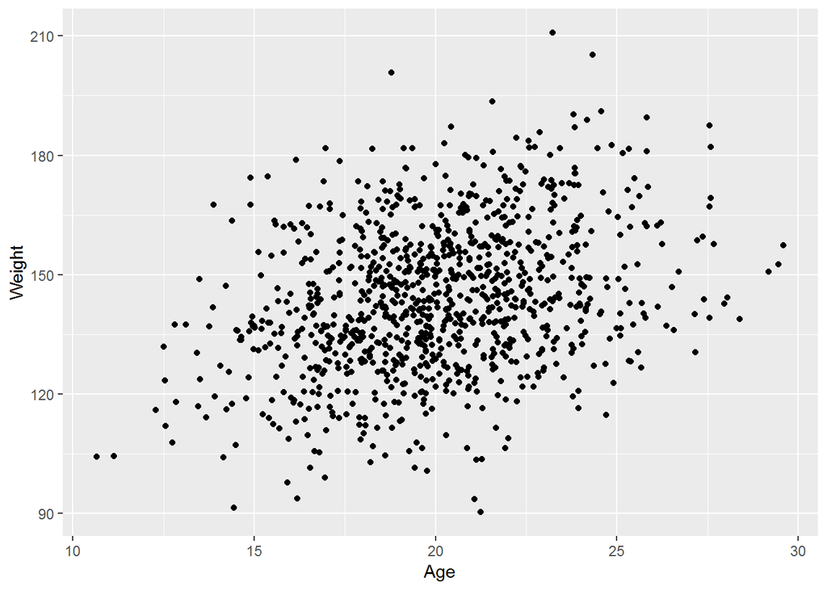

```r
wscat <- ggplot(data = d, aes(x = age, y = weight)) + xlab("Age") + ylab("Weight") + geom_point(na.rm = TRUE) + theme(legend.position = "bottom", legend.title = element_blank())
wscat
```

2.d. Using histograms and Q-Q plots, check whether the quantitative variables seem to be drawn from a normal distribution. Which seem to be and which do not? *Kills and Edu are not from normal distributions*

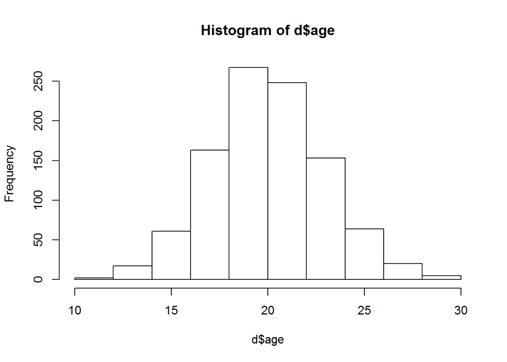

```r
hist(d$age)
```

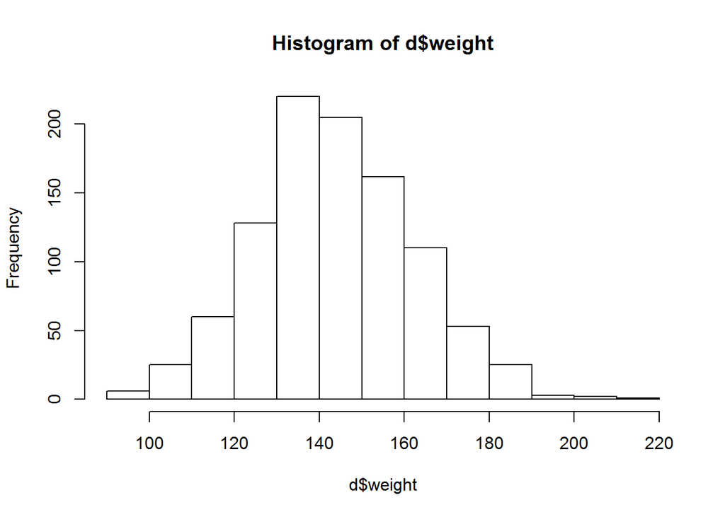

```r
hist(d$weight)
```

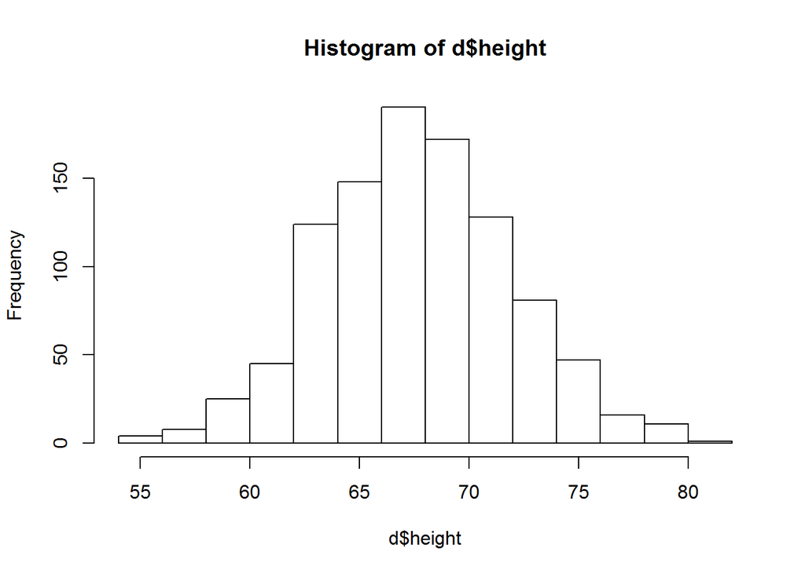

```r
hist(d$height)
```

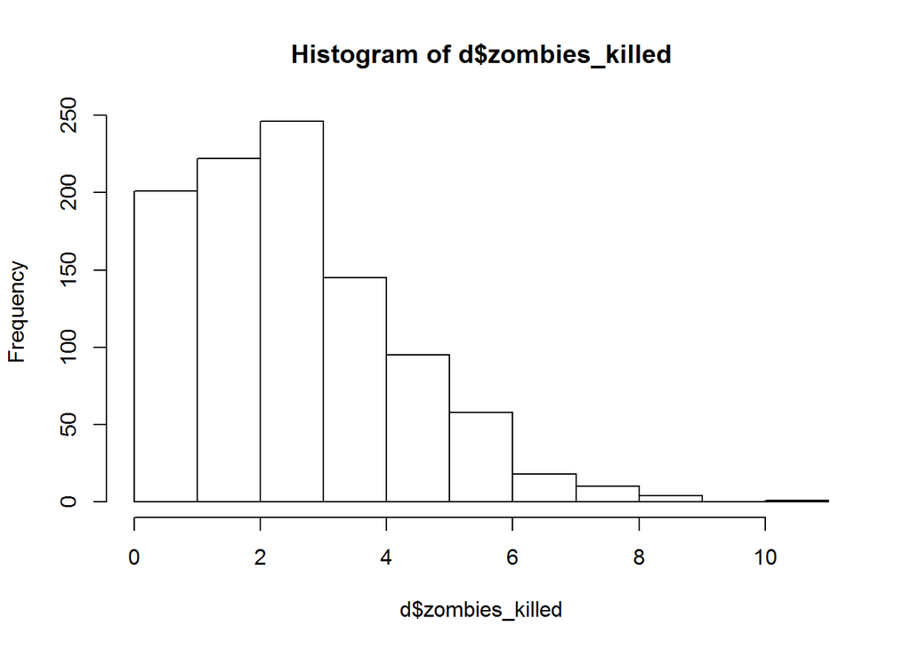

```r
hist(d$zombies_killed)
```

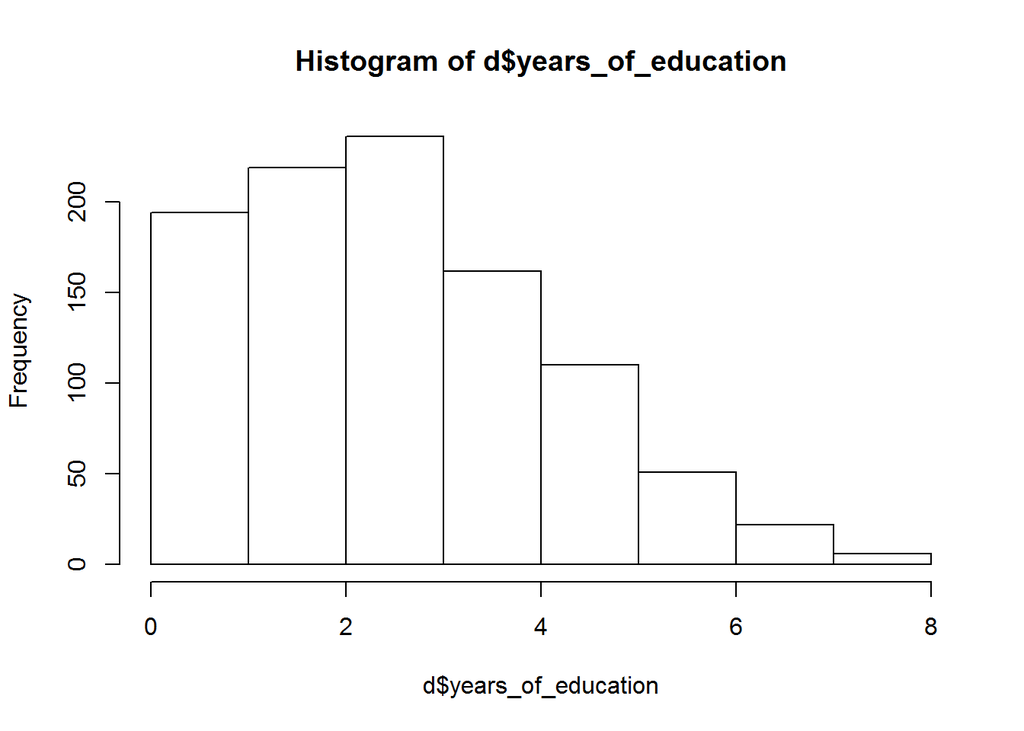

```r
hist(d$years_of_education)
```

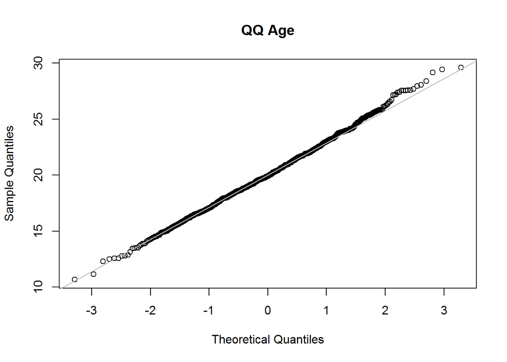

```r
qqnorm(d$age, main = "QQ Age")
qqline(d$age, col = "gray")
```

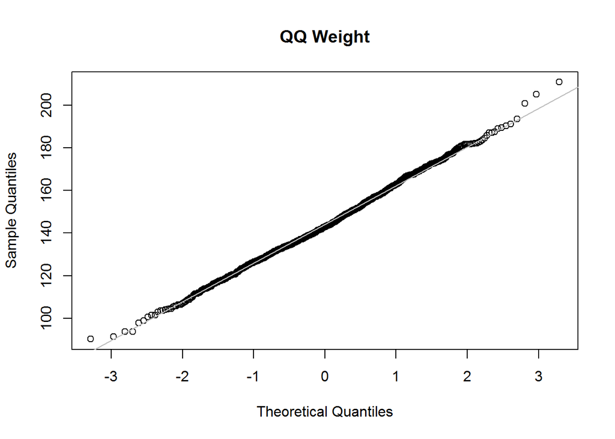

```r
qqnorm(d$weight, main = "QQ Weight")
qqline(d$weight, col = "gray")
```

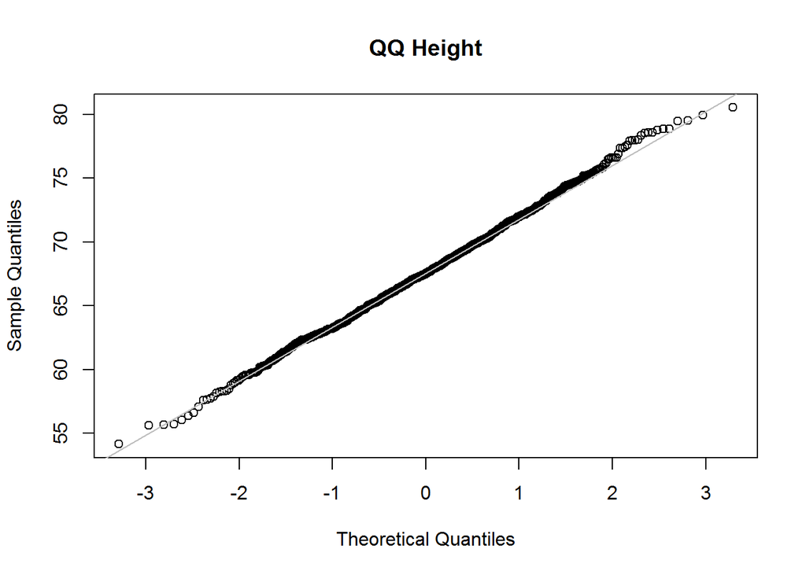

```r
qqnorm(d$height, main = "QQ Height")
qqline(d$height, col = "gray")
```

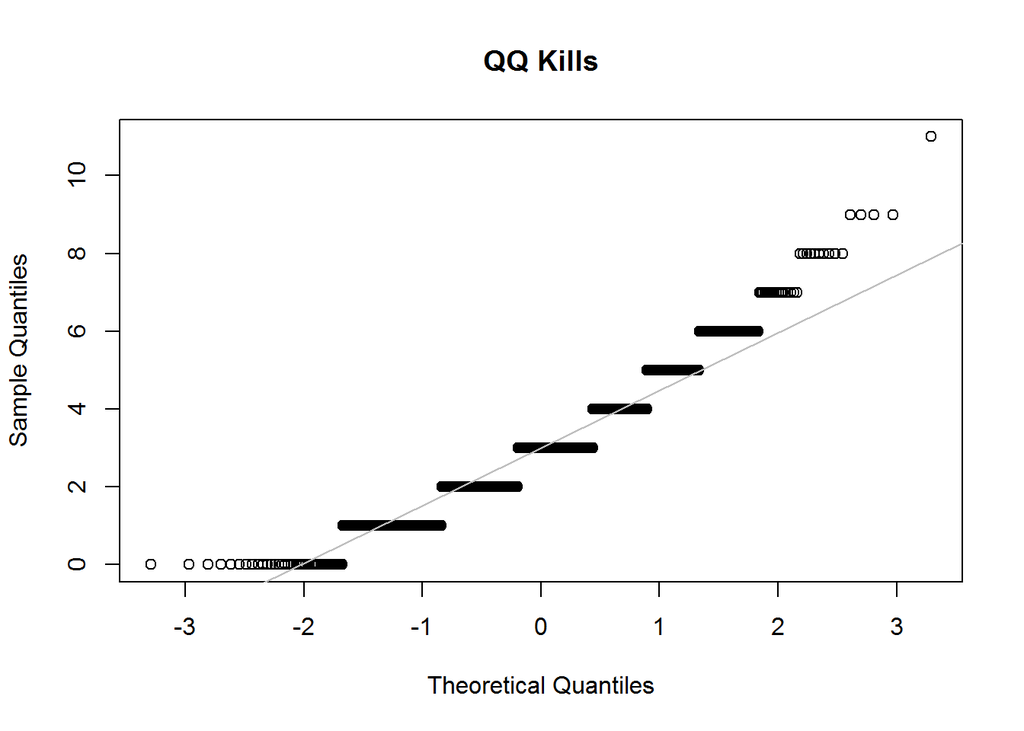

```r
qqnorm(d$zombies_killed, main = "QQ Kills")
qqline(d$zombies_killed, col = "gray")
```

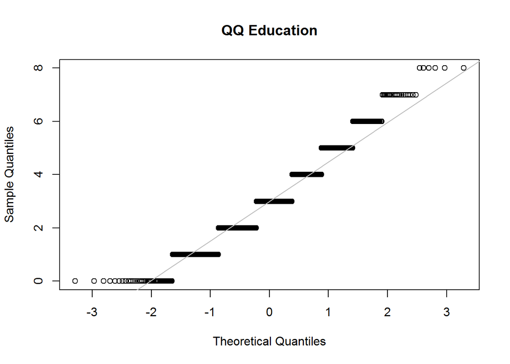

```r
qqnorm(d$years_of_education, main = "QQ Education")
qqline(d$years_of_education, col = "gray")
```

HINT: Not all are drawn from a normal distribution! For those that are not, can you determine what common distribution they are drawn from?

2.e. Now use the sample() function to sample ONE subset of 30 zombies (without replacement) from this population and calculate the mean and sample standard deviation for each variable. Also estimate the standard error for each variable and construct the 95% confidence interval for each mean. Note that for the variables that are not drawn from the normal distribution, you will need to base your estimate of the CIs on some different distribution!

```r
k <- 1  # number of subsets taken
n <- 30  # subset size
group <- NULL  # dummy

for (i in 1:k) {
  group <- sample(1:nrow(sel_data), size = n, replace = FALSE)
}

x <- sel_data[group, ]
x
```

```
##       height      age   weight zombies_killed years_of_education
## 205 72.67681 20.02906 161.1856              2                  2
## 222 67.80250 16.74823 142.8491              2                  1
## 872 68.84493 24.00616 138.4296              3                  7
## 633 70.18293 19.30563 151.6263              1                  2
## 378 67.67221 22.96536 136.6428              5                  4
## 724 68.65733 21.26049 149.5908              1                  2
## 263 68.63621 19.17136 158.8520              0                  2
## 7   70.26459 20.53096 160.2569              0                  4
## 351 64.59859 21.93930 132.5271              4                  4
## 356 70.42895 23.05967 134.4735              2                  4
## 240 67.29899 17.96663 145.7219              5                  3
## 118 65.21957 18.81568 143.4853              2                  4
## 10  72.81769 21.50798 168.5616              2                  3
## 362 65.60196 21.64507 126.5876              2                  1
```

[output cut: 16 more lines]

** means**

```r
hm <- mean(x$height)
hm
```

```
## [1] 68.31809
```

```r
am <- mean(x$age)
am
```

```
## [1] 21.1469
```

```r
wm <- mean(x$weight)
wm
```

```
## [1] 144.5879
```

```r
zm <- mean(x$zombies_killed)
zm
```

```
## [1] 2.833333
```

```r
em <- mean(x$years_of_education)
em
```

```
## [1] 3.066667
```

** standard deviations**

```r
hsd <- sd(x$height)
hsd
```

```
## [1] 2.43664
```

```r
asd <- sd(x$age)
asd
```

```
## [1] 2.396943
```

```r
wsd <- sd(x$weight)
wsd
```

```
## [1] 13.74395
```

```r
zsd <- sd(x$zombies_killed)
zsd
```

```
## [1] 1.555487
```

```r
esd <- sd(x$years_of_education)
esd
```

```
## [1] 1.552158
```

**standard errors**

```r
library(sciplot)
hse <- se(x$height)
hse
```

```
## [1] 0.4448675
```

```r
ase <- se(x$age)
ase
```

```
## [1] 0.4376199
```

```r
wse <- se(x$weight)
wse
```

```
## [1] 2.509291
```

```r
zse <- se(x$zombies_killed)
zse
```

```
## [1] 0.2839918
```

```r
ese <- se(x$years_of_education)
ese
```

```
## [1] 0.283384
```

**confidence intervals**

```r
upperheight <- hm + qnorm(0.975, mean = 0, sd = 1) * hse
lowerheight <- hm + qnorm(0.025, mean = 0, sd = 1) * hse
hci <- c(lowerheight, upperheight)
hci
```

```
## [1] 67.44617 69.19001
```

```r
upperage <- am + qnorm(0.975, mean = 0, sd = 1) * ase
lowerage <- am + qnorm(0.025, mean = 0, sd = 1) * ase
aci <- c(lowerage, upperage)
aci
```

```
## [1] 20.28918 22.00462
```

```r
upperweight <- wm + qnorm(0.975, mean = 0, sd = 1) * wse
lowerweight <- wm + qnorm(0.025, mean = 0, sd = 1) * wse
wci <- c(lowerweight, upperweight)
wci
```

```
## [1] 139.6698 149.5060
```

```r
upperkills <- zm + qnorm(0.975, mean = 0, sd = 1) * zse
lowerkills <- zm + qnorm(0.025, mean = 0, sd = 1) * zse
zci <- c(lowerkills, upperkills)
zci
```

```
## [1] 2.276720 3.389947
```

```r
upperedu <- em + qnorm(0.975, mean = 0, sd = 1) * ese
loweredu <- em + qnorm(0.025, mean = 0, sd = 1) * ese
eci <- c(loweredu, upperedu)
eci
```

```
## [1] 2.511244 3.622089
```

2.f. Now draw 99 more random samples of 30 zombies out and calculate the mean for each of the these samples. Together with the first sample you drew out, you now have a set of 100 means for each variable (each based on 30 observations), which constitutes a sampling distribution for each variable. What are the means and standard deviations of the sampling distribution for each variable?

```r
set.seed(1)
k <- 99  # number of subsets taken
n <- 30  # subset size
biggroup <- NULL  # dummy

for (i in 1:99) {
  biggroup[[i]] <- sample(1:nrow(sel_data), size = 30, replace = FALSE)
}

t <- sel_data[biggroup[[i]], ]
t
```

```
##       height      age   weight zombies_killed years_of_education
## 63  63.16399 16.78669 126.6091              1                  3
## 997 66.48566 19.87402 157.0878              3                  2
## 114 72.66829 19.19078 176.6687              2                  3
## 624 63.42365 17.07766 131.4085              2                  3
## 26  66.21361 18.82527 147.5891              1                  3
## 69  67.17319 20.81643 137.0979              1                  2
## 188 71.49300 19.91412 162.2126              5                  3
## 795 70.09081 16.55408 160.1624              5                  3
## 829 63.24188 18.85515 128.4248              1                  3
## 719 73.81399 27.37130 159.5498              4                  3
## 278 74.59113 20.23903 183.0497              7                  4
## 636 69.74712 20.39527 143.6522              1                  3
## 948 70.19100 23.41001 160.5423              2                  1
## 531 69.32048 24.53695 140.0381              2                  2
```

[output cut: 16 more lines]

```r
y <- rbind(t, x)
y
```

```
##        height      age   weight zombies_killed years_of_education
## 63   63.16399 16.78669 126.6091              1                  3
## 997  66.48566 19.87402 157.0878              3                  2
## 114  72.66829 19.19078 176.6687              2                  3
## 624  63.42365 17.07766 131.4085              2                  3
## 26   66.21361 18.82527 147.5891              1                  3
## 69   67.17319 20.81643 137.0979              1                  2
## 188  71.49300 19.91412 162.2126              5                  3
## 795  70.09081 16.55408 160.1624              5                  3
## 829  63.24188 18.85515 128.4248              1                  3
## 719  73.81399 27.37130 159.5498              4                  3
## 278  74.59113 20.23903 183.0497              7                  4
## 636  69.74712 20.39527 143.6522              1                  3
## 948  70.19100 23.41001 160.5423              2                  1
## 531  69.32048 24.53695 140.0381              2                  2
```

[output cut: 46 more lines]

**Group Means**

```r
mgh <- mean(y$height)
mgh
```

```
## [1] 67.96346
```

```r
mga  <- mean(y$age)
mga
```

```
## [1] 20.6924
```

```r
mgw <- mean(y$weight)
mgw
```

```
## [1] 145.3926
```

```r
mgz <- mean(y$zombies_killed)
mgz
```

```
## [1] 2.8
```

```r
mge <- mean(y$years_of_education)
mge
```

```
## [1] 2.933333
```

**group standard deviations**

```r
hgsd <- sd(y$height)
hgsd
```

```
## [1] 3.170333
```

```r
agsd <- sd(y$age)
agsd
```

```
## [1] 2.668809
```

```r
wgsd <- sd(y$weight)
wgsd
```

```
## [1] 15.15033
```

```r
zgsd <- sd(y$zombies_killed)
zgsd
```

```
## [1] 1.592355
```

```r
egsd <- sd(y$years_of_education)
egsd
```

```
## [1] 1.45982
```

What do these sampling distributions look like?

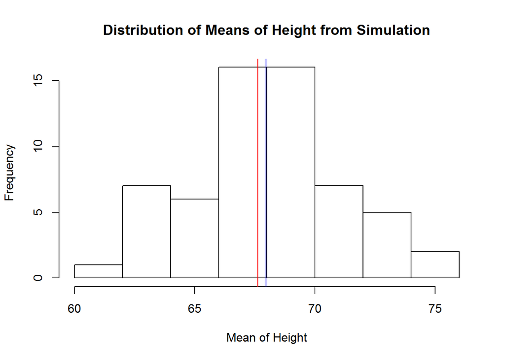

```r
hist(y$height, xlab = "Mean of Height", main = "Distribution of Means of Height from Simulation")
abline(v = mgh, col = "blue")
abline(v = mean(d$height), col = "red")
```

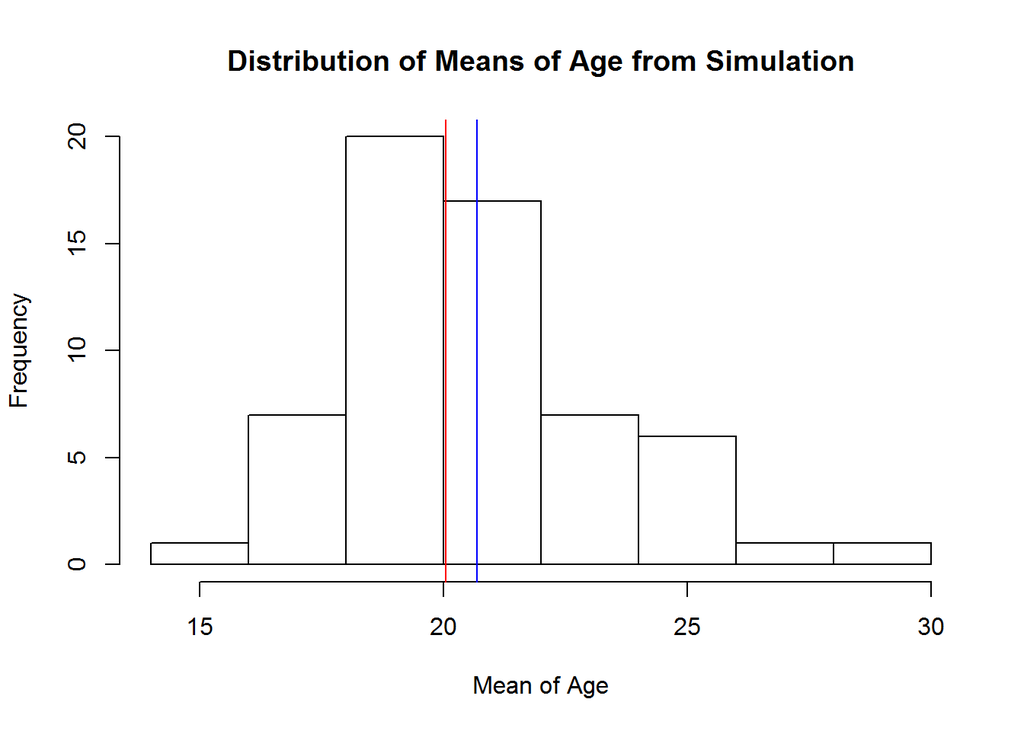

```r
hist(y$age, xlab = "Mean of Age", main = "Distribution of Means of Age from Simulation")
abline(v = mga, col = "blue")
abline(v = mean(d$age), col = "red")
```

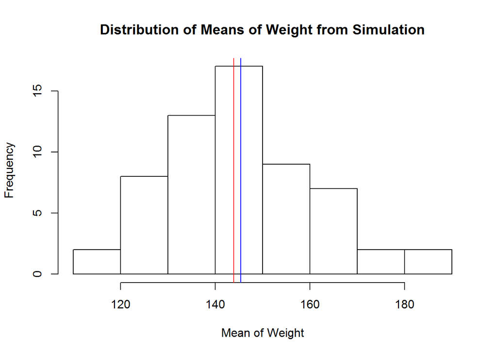

```r
hist(y$weight, xlab = "Mean of Weight", main = "Distribution of Means of Weight from Simulation")
abline(v = mgw, col = "blue")
abline(v = mean(d$weight), col = "red")
```

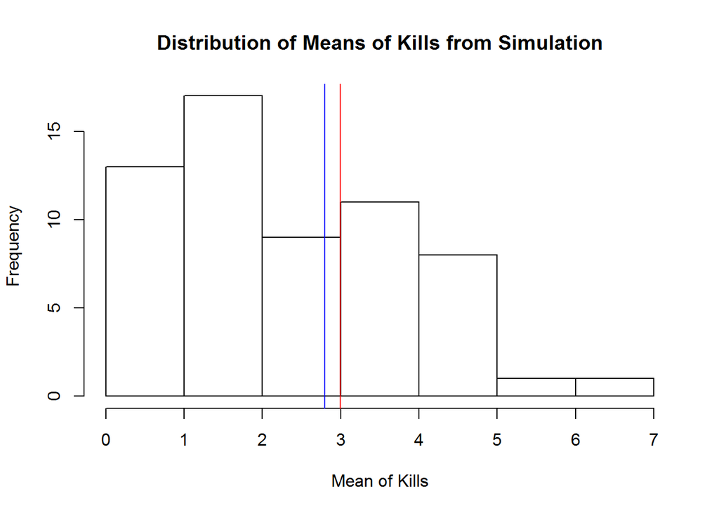

```r
hist(y$zombies_killed, xlab = "Mean of Kills", main = "Distribution of Means of Kills from Simulation")
abline(v = mgz, col = "blue")
abline(v = mean(d$zombies_killed), col = "red")
```

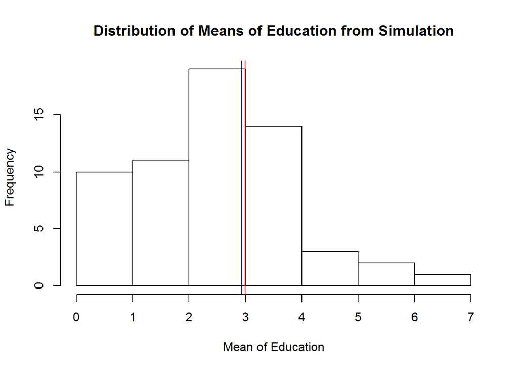

```r
hist(y$years_of_education, xlab = "Mean of Education", main = "Distribution of Means of Education from Simulation")
abline(v = mge, col = "blue")
abline(v = mean(d$years_of_education), col = "red")
```

When you are done, “knit” your R Markdown file to .html and push both your .Rmd and .html files up to GitHub for me to look at.